# R Notebook

species group specific PCAs to understand patterns of mis-assignment.

```r
library(tidyverse)
library(adegenet)
library("ape")
library("pegas")
library(RColorBrewer)
library(wordcloud) # for non-overlapping labels
```

read in genepop data

```r
maliger <- read.genepop("../new_baseline_data/processed/maliger_caurinus_atrovirens.gen", ncode = 3)
```

```
 Converting data from a Genepop .gen file to a genind object...


File description:  Title Line: maliger and caurinus.  NumInds= 1042 NumLoc= 90
```

```
Duplicate individual names detected. Coercing them to be unique.
```

```
...done.
```

make a basic PCA following the adegenet tutorial

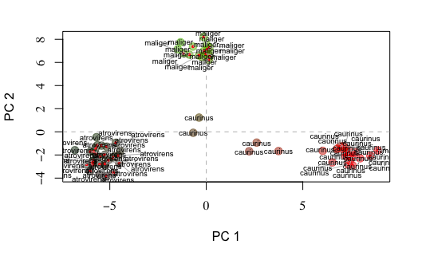

Based on this it looks pretty clear that that maliger sample is mis-labeled.

Can we look at the Fst value between maliger and caurinus?

```r
matFst
```

```
          1         2
2 0.2065341
3 0.1422051 0.1931631
```

## southern california species

```r
socal <- read.genepop("../new_baseline_data/processed/southerncalif_spp.gen", ncode = 3)
```

```
 Converting data from a Genepop .gen file to a genind object...


File description:  Title Line: File converted from a gsi sim file.  NumInds= 1042 NumLoc= 90
```

```
Duplicate individual names detected. Coercing them to be unique.
```

```
...done.
```

make a basic PCA following the adegenet tutorial

```r
# Allele presence absence data are extracted and NAs replaced using tab:
S <- tab(socal, NA.method="mean")
# make PCA
socal.pca <- dudi.pca(S,scannf=FALSE,scale=FALSE)
# plot PCA
pdf("pdf_outputs/socal_pca_v2.pdf", width = 10, height = 10)
colorplot(socal.pca$li, socal.pca$li, transp=TRUE, cex=2, font=5, xlab="PC 1", ylab="PC 2")
abline(v=0,h=0,col="grey", lty=2)
textplot(socal.pca$li[,1], socal.pca$li[,2], words=pop(socal), cex=.6, new=FALSE)
dev.off()
```

The resolution among the southern CA species is challenging - what is the Fst value between each group?

```r
socal.fst
```

```
            1           2           3           4           5           6
2  0.42583077
3  0.48816065  0.08732817
4  0.39746418  0.06775561  0.06903744
5  0.38811995  0.03040319  0.05035166  0.04655609
6  0.22985055  0.02530682 -0.01225725  0.02152979  0.04311406
7  0.28854606  0.06061354  0.08275533 -0.01339329  0.25423062  0.15447069
8  0.56623504  0.13874422  0.24336539  0.12533700  0.16544888  0.06330946
9  0.59955613  0.44755389  0.45878139  0.41303616 -0.03516434  0.09108694
            7           8
2
3
4
5
6
7
8  0.13893362
9 -0.76316656  0.49100614
```

## kgbc and friends

Read in the data to increase resolution for that cluster

```r
kgbc <- read.genepop("../new_baseline_data/processed/kgbc_plus.gen", ncode = 3)
```

make a basic PCA following the adegenet tutorial

```r
# Allele presence absence data are extracted and NAs replaced using tab:
k <- tab(kgbc, NA.method="mean")

# make PCA
kgbc.pca <- dudi.pca(k,scannf=FALSE,scale=FALSE)

# plot PCA
pdf("pdf_outputs/kgbc_pca.pdf", width = 10, height = 10)
colorplot(kgbc.pca$li, kgbc.pca$li, transp=TRUE, cex=2, font=5, xlab="PC 1", ylab="PC 2")
abline(v=0,h=0,col="grey", lty=2)
textplot(kgbc.pca$li[,1], kgbc.pca$li[,2], words=pop(kgbc), cex=.6, new=FALSE)
dev.off()
```

## New PCA after removing the helvomaculatus, brevispinis, simulator, and revising the identity of the single maliger sample that is clearly misidentified and is actually caurinus

```r
# Read in the data
new.pca <- read.genepop("../new_baseline_data/processed/sebastes_no_helv_sim_brev.gen", ncode = 3)
```

[output not shown]

```
Duplicate individual names detected. Coercing them to be unique.
```

```
...done.
```

make a basic PCA following the adegenet tutorial

```r
sebastes.pca
```

```
Duality diagramm
class: pca dudi
$call: dudi.pca(df = sebs, scale = FALSE, scannf = FALSE)

$nf: 2 axis-components saved
$rank: 1021
eigen values: 17.42 11.38 9.49 8.977 6.588 ...
  vector length mode    content
1 $cw    2418   numeric column weights
2 $lw    1032   numeric row weights
3 $eig   1021   numeric eigen values

  data.frame nrow ncol content
1 $tab       1032 2418 modified array
2 $li        1032 2    row coordinates
3 $l1        1032 2    row normed scores
4 $co        2418 2    column coordinates
5 $c1        2418 2    column normed scores
other elements: cent norm
```

## New PCA Fst summary stats

Maybe to be used for ascertainment bias stuff?

```r
fstat(new.pca)
```

```
            pop       Ind
Total 0.7207112 0.7515022
pop   0.0000000 0.1102478
```

```r
matFst
```

```
              atrovirens chrysomelas   carnatus  caurinus    maliger
atrovirens    0.00000000  0.10462150 0.10276504 0.2065341 0.14220506
chrysomelas   0.10462150  0.00000000 0.01466292 0.1671048 0.09658070
carnatus      0.10276504  0.01466292 0.00000000 0.1688072 0.09781059
caurinus      0.20653407  0.16710482 0.16880719 0.0000000 0.19316312
maliger       0.14220506  0.09658070 0.09781059 0.1931631 0.00000000
nebulosus     0.22485156  0.18563526 0.18691285 0.3429444 0.25325062
dallii        0.21005570  0.22187261 0.22170360 0.3342139 0.30485905
rastrelliger  0.23860019  0.25253585 0.26174085 0.4151304 0.36552686
auriculatus   0.24500269  0.25333916 0.24780331 0.3960976 0.36825244
saxicola      0.26914268  0.26994190 0.27209273 0.4216244 0.39013465
semicinctus   0.27854967  0.27758508 0.28045290 0.4272774 0.39520147
elongatus     0.27771431  0.29455696 0.29634572 0.4252499 0.42049629
miniatus      0.33563520  0.35457149 0.35710890 0.4789882 0.46148117
pinniger      0.31109029  0.32498915 0.32462386 0.4677767 0.46574044
oculatus      0.30242210  0.31001087 0.30970010 0.4405934 0.43246972
constellatus  0.28129785  0.29321529 0.28991683 0.4119304 0.41340939
umbrosus      0.28248395  0.28733229 0.28322363 0.4077429 0.38795640
rosaceus      0.24407432  0.24828385 0.24487808 0.3644164 0.33532377
              nebulosus    dallii rastrelliger auriculatus  saxicola
atrovirens    0.2248516 0.2100557    0.2386002   0.2450027 0.2691427
chrysomelas   0.1856353 0.2218726    0.2525359   0.2533392 0.2699419
carnatus      0.1869128 0.2217036    0.2617408   0.2478033 0.2720927
caurinus      0.3429444 0.3342139    0.4151304   0.3960976 0.4216244
maliger       0.2532506 0.3048590    0.3655269   0.3682524 0.3901346
nebulosus     0.0000000 0.4115306    0.4423622   0.4691269 0.4685474
dallii        0.4115306 0.0000000    0.4189856   0.4487725 0.4883168
rastrelliger  0.4423622 0.4189856    0.0000000   0.6174315 0.5970924
auriculatus   0.4691269 0.4487725    0.6174315   0.0000000 0.6465355
saxicola      0.4685474 0.4883168    0.5970924   0.6465355 0.0000000
semicinctus   0.4662875 0.4991605    0.6098026   0.6394495 0.3323861
elongatus     0.4997082 0.4881537    0.5805047   0.6077167 0.5241931
miniatus      0.5849070 0.5367959    0.6346205   0.6525777 0.5822640
pinniger      0.5427997 0.5528623    0.6400952   0.6790012 0.5959897
oculatus      0.5306694 0.4813724    0.5509611   0.6127621 0.5528568
constellatus  0.5020873 0.4608603    0.5536398   0.5871165 0.5320986
umbrosus      0.4752908 0.4119116    0.5178932   0.5419277 0.4559111
rosaceus      0.4271143 0.3599973    0.4413786   0.4666227 0.4132292
              semicinctus elongatus  miniatus  pinniger  oculatus
atrovirens      0.2785497 0.2777143 0.3356352 0.3110903 0.3024221
```

[output cut: 155 more lines]

```
maliger       0.39349987 0.4423803 0.4362685 0.5302457 0.3539738
nebulosus     0.47123598 0.5330695 0.5139808 0.6489006 0.4314700
dallii        0.44040415 0.5204596 0.5224551 0.5987876 0.4764069
rastrelliger  0.52433119 0.6184950 0.6454932 0.7090933 0.5644917
auriculatus   0.54237651 0.6362691 0.6671419 0.7080658 0.6613114
saxicola      0.48649371 0.5548077 0.5848103 0.6670938 0.6006897
semicinctus   0.52402750 0.5649149 0.5808436 0.6693498 0.6194118
elongatus     0.43559368 0.5130306 0.5220636 0.5953002 0.4622391
miniatus      0.53593638 0.5313705 0.5006197 0.6071947 0.4652747
pinniger      0.49141959 0.5915586 0.5572364 0.6822724 0.4974569
oculatus      0.47048199 0.5375526 0.4943037 0.6590225 0.4540057
constellatus  0.46638555 0.5250477 0.4865078 0.6421240 0.4488660
umbrosus      0.41966858 0.4928147 0.4429527 0.6042827 0.3530334
rosaceus      0.37559390 0.4069016 0.3789351 0.5293136 0.3104123
 [ reached getOption("max.print") -- omitted 36 rows ]
```

(a bunch of markers with missing data for one or more populations were removed.)

Make a tree?

[figure not shown]

Make a plot-thing?

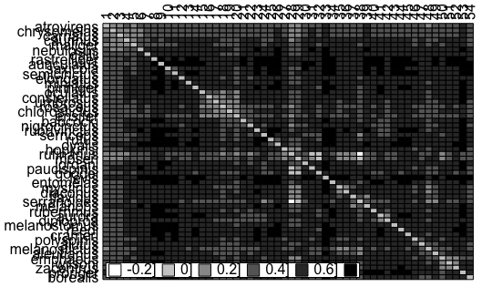

And then the boxplot

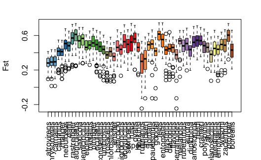

I wonder how much of this is influenced by the number of loci that were removed?

New test PCA

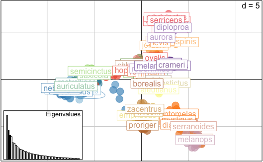

Check out the first two PCs and then PCs 2 and 3

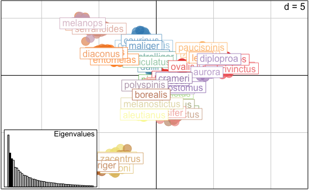

```r
# PCs 2 and 3
s.class(pca.seb$li, fac=pop(new.pca),
        xax=2, yax=3, col=transp(funky(54),.7),
        axesel=FALSE, cstar=0, cpoint=3)
add.scatter.eig(pca.seb$eig[1:50],3,2,3, ratio=.3)
```